# Evaluation of hyperparameters and model structure in CNNs

## Nick Serger

This evaluation was originally conducted as the final project for George Mason University's ECE 527: Learning from Data (Machine Learning). The notebook has been further improved since.

The evaluation is performed on the CIFAR10 dataset.

**Click to view how each model differed from Model 1**

**Click to view all full model structures**

Final Model: 10 layer CNN (input, conv(32), conv(32), maxPool, conv(64), conv(64), maxPool, dense(1024), dense(512), dense(num_classes, 'softmax')

```
1. Trained with 25% dropout after maxPool layers and 50% dropout after the first two dense layers
2. All convolutional layers have a kernel_size of (3, 3)
3. All pooling layers have a pool_size of (2, 2)
4. All convolutional and dense layers use relu activation function except for the final dense layer
5. Using the Adam optimizer and categorical_crossentropy loss
6. Batch size of 128 and 60 epochs
7. Batch normalization used before each pooling layer
8. Data Augmentation used to increase the amount of training data
```

Following the evaluation of the final model on the test data, there is a brief analysis of different hyperparameters and model structure and how changes can impact a model's performance.

### Initial model setup

Several models will be built, changing parameter values slightly and comparing to the original model output. Once the optimal parameters have been decided, the final model will be produced.

#### Load the required imports

```python
import keras
from keras.datasets import cifar10
from keras.layers import Dense, Dropout, Flatten
from keras.layers import Conv2D, MaxPooling2D, BatchNormalization
from keras.preprocessing.image import ImageDataGenerator
from keras.models import Sequential
import matplotlib.pyplot as plt
from keras import backend as K
```

#### Load, reshape, and normalize the data

```python
num_classes = 10
img_x, img_y = 32, 32

# The data, split between train and test sets:
(x_train, y_train), (x_test, y_test) = cifar10.load_data()
print('x_train shape: {}'.format(x_train.shape))
print('{} train samples'.format(x_train.shape[0]))
print('{} test samples'.format(x_test.shape[0]))

# Normalize the data
x_train = x_train.astype('float32')
x_test = x_test.astype('float32')
x_train /= 255
x_test /= 255

# Convert class vectors to binary class matricies
y_train = keras.utils.to_categorical(y_train, num_classes)
y_test = keras.utils.to_categorical(y_test, num_classes)
```

```
x_train shape: (50000, 32, 32, 3)
50000 train samples
10000 test samples
```

#### Function to build the model

```python
def build_model(conv_unit_1=32,
                      conv_unit_2=64,
                      kernel_size_1=(3, 3),
                      kernel_size_2=(3, 3),
                      pool_size=(2, 2),
                      batch_norm=False,
                      dense_unit_1=512,
                      dense_unit_2=0):
    """Builds a CNN model.

    Arguments:
      conv_unit_1: Integer (default=64), number of output filters in the
          first two convolutions
      conv_unit_2: Integer (default=64), number of output filters in the
          second two convolutions
      kernel_size_1: Tuple of 2 integers (default=(3, 3), for the first
          two convolutions specifying the height and width of the 2D
          convolution window.
      kernel_size_2: Tuple of 2 integers (default=(3, 3), for the second
          two convolutions specifying the height and width of the 2D
          convolution window.
      pool_size: Integer (default=(2, 2)), size of the max pooling windows.
      batch_norm: Boolean (default=False), normalizing the data in the
          batch after the two convolution steps
      dense_unit_1: Positive integer (default=512), dimensionality of the
          output space for the first dense layer
      dense_unit_2: Positive integer (default=0), dimensionality of the
          output space for the second dense layer. If 0 then there is
          only one dense layer.

    Returns:
      The CNN model.
    """

    model = Sequential()
    model.add(Conv2D(conv_unit_1, kernel_size=kernel_size_1,
                     activation='relu',
                     input_shape=x_train.shape[1:]))
    model.add(Conv2D(conv_unit_1, kernel_size_1, activation='relu'))
    if batch_norm:
        model.add(BatchNormalization())
    model.add(MaxPooling2D(pool_size=pool_size))
    model.add(Dropout(0.25))

    model.add(Conv2D(conv_unit_2, kernel_size=kernel_size_2,
                     activation='relu'))
    model.add(Conv2D(conv_unit_2, kernel_size_2, activation='relu'))
    if batch_norm:
        model.add(BatchNormalization())
    model.add(MaxPooling2D(pool_size=pool_size))
    model.add(Dropout(0.25))

    model.add(Flatten())
    model.add(Dense(dense_unit_1, activation='relu'))
    if dense_unit_2 > 0:
        model.add(Dropout(0.5))
        model.add(Dense(dense_unit_2, activation='relu'))
    model.add(Dropout(0.5))
    model.add(Dense(num_classes, activation='softmax'))

    return model
```

#### Function to compile the model

```python
def compile_model(model, optimizer='Adam'):
    """Compiles the already built model.

    Arguments:
      optimizer: The optimizer (default='Adam') options are:
          (SGD, RMSprop, Adadelta, Adam)

    Returns:
      The compiled model.
    """
    if optimizer == 'SGD':
        opt = keras.optimizers.SGD()
    elif optimizer == 'Adadelta':
        opt = keras.optimizers.Adadelta()
    elif optimizer == 'RMSprop':
        opt = keras.optimizers.RMSprop()
    else:
        opt = keras.optimizers.Adam()

    model.compile(loss=keras.losses.categorical_crossentropy,
                  optimizer=opt,
                  metrics=['accuracy'])

    return model
```

#### Function to train the model

```python
def fit_model(model, batch_size=128, epochs=40, validation_split=0.2):
    """Trains the compiled model.

    Arguments:
      model: compiled model returned from the function "compile_model"
      x_train: Input data
      y_train: Target data
      batch_size: Integer (default=128), number of samples per gradient update.
      epochs: Integer. Integer (default=30), number of epochs to train the model.
      validation_split: Float between 0 and 1. Fraction of the training
          data to be used as validation data.

    Returns:
      The history object returned from the keras function model.fit()
    """
    return model.fit(x_train, y_train,
                      batch_size=batch_size,
                      epochs=epochs,
                      verbose=1,
                      validation_split=validation_split,
                      callbacks=None) #[history])
```

#### Function to evaluate the model

```python
def evaluate_model(model, x_test, y_test):
    """
    Prints the test loss and test accuracy of the model.

    This function should only be run on the final model so as
    not to "taint" the results by using the test data to inform
    model building decisions.

    Arguments:
      model: The trained model.
      x_test: The input test data
      y_test: The target test data

    Returns:
      Prints the test loss and test accuracy of the model.
    """
    score = model.evaluate(x_test, y_test, verbose=0)
    print('\nTest loss: {}'.format(score[0]))
    print('Test accuracy: {}'.format(score[1]))

    return score
```

#### Function to make a comparison plot

```python
def plot_comparison(hist1, model1, hist2, model2):
    """
    Generate two plots to compare two models.

    The first plot compares the training accuracy of the two models. And
    the second plot compares the validation accuracy.

    Arguments:
      hist1: History object, the history for model1
      model1: String, the model number for hist1 that is being compared
      hist2: History object, the history for model2
      model2: String, the model number for hist2 that is being compared

    Results:
      One plot of the training accuracy and one plot of the validation
      accuracy.
    """
    fig, ax = plt.subplots(1, 2, figsize=(15, 7))

    ax[0].plot(hist1.history['accuracy'], label = 'Model {} train'.format(model1), color = 'orange')
    ax[0].plot(hist2.history['accuracy'], label = 'Model {} train'.format(model2), color = 'r')
    ax[0].set_title('Training Accuracy for Model {} and Model {}'.format(model1, model2))
    ax[0].set_ylabel('accuracy')
    ax[0].set_xlabel('epoch')
    ax[0].legend()

    ax[1].plot(hist1.history['val_accuracy'], label = 'Model {} validation'.format(model1), color = 'orange')
    ax[1].plot(hist2.history['val_accuracy'], label = 'Model {} validation'.format(model2), color = 'r')
    ax[1].set_title('Validation Accuracy for Model {} and Model {}'.format(model1, model2))
    ax[1].set_ylabel('accuracy')
    ax[1].set_xlabel('epoch')
    ax[1].legend()

    plt.show()
```

Model using kernel size of (3, 3) for all convolutional layers with relu activation functions and has two sets of two convolutional layers. The first set has 32 filters each and the second set has 64 filters each. After each set of convolutional layers is a maxpooling layer with a pool size of (2, 2). After each maxpooling layer is 25% dropout. Following the second dropout is a dense 512 unit layer. Followed by 50% dropout then the final dense layer that uses a softmax activation function.

```python
model1 = build_model(conv_unit_1=32,
                      conv_unit_2=64,
                      kernel_size_1=(3, 3),
                      kernel_size_2=(3, 3),
                      pool_size=(2, 2),
                      batch_norm=False,
                      dense_unit_1=512,
                      dense_unit_2=0)

model1 = compile_model(model1, 'Adam')
```

```python
model1.summary()
```

```
Model: "sequential_1"
_________________________________________________________________
Layer (type)                 Output Shape              Param #
=================================================================
conv2d_1 (Conv2D)            (None, 30, 30, 32)        896
_________________________________________________________________
conv2d_2 (Conv2D)            (None, 28, 28, 32)        9248
_________________________________________________________________
max_pooling2d_1 (MaxPooling2 (None, 14, 14, 32)        0
_________________________________________________________________
dropout_1 (Dropout)          (None, 14, 14, 32)        0
_________________________________________________________________
conv2d_3 (Conv2D)            (None, 12, 12, 64)        18496
_________________________________________________________________
conv2d_4 (Conv2D)            (None, 10, 10, 64)        36928
_________________________________________________________________
max_pooling2d_2 (MaxPooling2 (None, 5, 5, 64)          0
_________________________________________________________________
dropout_2 (Dropout)          (None, 5, 5, 64)          0
_________________________________________________________________
flatten_1 (Flatten)          (None, 1600)              0
_________________________________________________________________
dense_1 (Dense)              (None, 512)               819712
_________________________________________________________________
dropout_3 (Dropout)          (None, 512)               0
_________________________________________________________________
dense_2 (Dense)              (None, 10)                5130
=================================================================
Total params: 890,410
Trainable params: 890,410
Non-trainable params: 0
_________________________________________________________________
```

```python
hist1 = fit_model(model1, batch_size=128, epochs=40, validation_split=0.2)
```

```
Train on 40000 samples, validate on 10000 samples
```

```python
# Print history of model
print('history contains: {}'.format(hist1.history))
```

[output not shown]

#### Model 1 validation accuracy

Model 1's final validation accuracy was 79.10%. The validation accuracy generated by each model after the final epoch of training will typically be the deciding factor about whether to include the changes to Model 1 into the final model.

### Model 2: Using a different structure

Model 2 uses a different structure than Model 1. Instead of conv-conv-pool conv-conv-pool flat-dense-dense the model's layers are conv-pool conv-pool conv-pool flat-dense-dense.

Before one can compare model hyperparameters, it is important to make sure that a good model is built.

```python
# Model Design
model2 = Sequential()
model2.add(Conv2D(32, kernel_size=(3, 3),
                 activation='relu',
                 input_shape=x_train.shape[1:]))
model2.add(MaxPooling2D(pool_size=(2, 2)))
model2.add(Dropout(0.25))

model2.add(Conv2D(64, (3, 3), activation='relu'))
model2.add(MaxPooling2D(pool_size=(2, 2)))
model2.add(Dropout(0.25))

model2.add(Conv2D(128, (3, 3), activation='relu'))
model2.add(MaxPooling2D(pool_size=(2, 2)))
model2.add(Dropout(0.25))

model2.add(Flatten())
model2.add(Dense(512, activation='relu'))
model2.add(Dropout(0.5))
model2.add(Dense(num_classes, activation='softmax'))
```

```python
model2.summary()
```

```
Model: "sequential_2"
_________________________________________________________________
Layer (type)                 Output Shape              Param #
=================================================================
conv2d_5 (Conv2D)            (None, 30, 30, 32)        896
_________________________________________________________________
max_pooling2d_3 (MaxPooling2 (None, 15, 15, 32)        0
_________________________________________________________________
dropout_4 (Dropout)          (None, 15, 15, 32)        0
_________________________________________________________________
conv2d_6 (Conv2D)            (None, 13, 13, 64)        18496
_________________________________________________________________
max_pooling2d_4 (MaxPooling2 (None, 6, 6, 64)          0
_________________________________________________________________
dropout_5 (Dropout)          (None, 6, 6, 64)          0
_________________________________________________________________
conv2d_7 (Conv2D)            (None, 4, 4, 128)         73856
_________________________________________________________________
max_pooling2d_5 (MaxPooling2 (None, 2, 2, 128)         0
_________________________________________________________________
dropout_6 (Dropout)          (None, 2, 2, 128)         0
_________________________________________________________________
flatten_2 (Flatten)          (None, 512)               0
_________________________________________________________________
dense_3 (Dense)              (None, 512)               262656
_________________________________________________________________
dropout_7 (Dropout)          (None, 512)               0
_________________________________________________________________
dense_4 (Dense)              (None, 10)                5130
=================================================================
Total params: 361,034
Trainable params: 361,034
Non-trainable params: 0
_________________________________________________________________
```

```python
# Compile the model
model2 = compile_model(model2)
```

```python
hist2 = fit_model(model2, batch_size=128, epochs=40, validation_split=0.2)
```

```
Train on 40000 samples, validate on 10000 samples
```

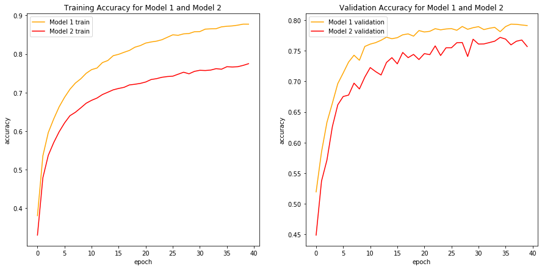

```python
plot_comparison(hist1, '1', hist2, '2')
```

#### Model 1 vs Model 2 analysis

As seem in the plots above, Model 2 has a lower training and validation accuracy compared to Model 1. The final validation accuracy for Model 2 was 75.67% and the final validation accuracy for Model 1 was 79.10%.

Model 2 having a lower validation accuracy than Model 1 is no surprise as Model 2 has fewer than half as many learnable parameters. Perhaps Model 2 would be useful in an application where model size needed to be kept below a threshold.

For the remainder of the analysis, Model 1's general structure will be used.

### Model 3: Exploring how many epochs to use when training models

Model 3 is trained for 100 epochs in order to identify when the Model 1 performance begins to plateau. Everything in Model 3 is the same as Model 1 except for the number of epochs.

```python
model3 = build_model(conv_unit_1=32,
                      conv_unit_2=64,
                      kernel_size_1=(3, 3),
                      kernel_size_2=(3, 3),
                      pool_size=(2, 2),
                      batch_norm=False,
                      dense_unit_1=512,
                      dense_unit_2=0)

model3 = compile_model(model3, 'Adam')
```

```python
hist3 = fit_model(model3, batch_size=128, epochs=100, validation_split=0.2)
```

```
Train on 40000 samples, validate on 10000 samples
```

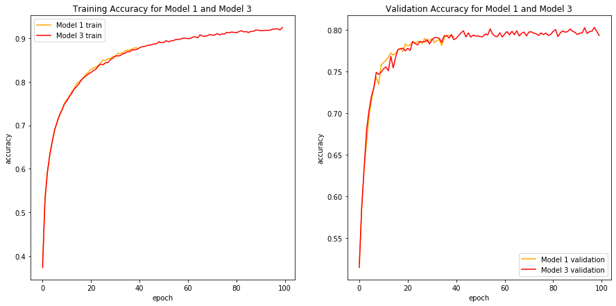

```python
plot_comparison(hist1, '1', hist3, '3')
```

```python
maxAccuracy3 = max(hist3.history['val_accuracy'])
print('The maximum validation accuracy was {}'.format(maxAccuracy3))

maxEpoch3 = hist3.history['val_accuracy'].index(maxAccuracy3)
print('The epoch where the max validation accuracy occured was {}'.format(maxEpoch3 + 1))
```

```
The maximum validation accuracy was 0.8026000261306763
The epoch where the max validation accuracy occured was 98
```

#### Model 1 vs Model 3 analysis

Based on the validation accuracy from the plot on the right, training each model for 40 epochs is a reasonable amount of training to ensure that the model has reached a plateau.

### Model 4: Using (5, 5) kernel size for the first convolutional layer set and (3, 3) kernel size for the second convolutional layer set

Model 4 is the same as Model 1 except that the first set of convolutional layers uses a (5, 5) kernel size. The intention is to explore if using varying kernel sizes will impact model performance.

```python
model4 = build_model(conv_unit_1=32,
                      conv_unit_2=64,
                      kernel_size_1=(5, 5),
                      kernel_size_2=(3, 3),
                      pool_size=(2, 2),
                      batch_norm=False,
                      dense_unit_1=512,
                      dense_unit_2=0)

model4 = compile_model(model4, 'Adam')
```

```python
hist4 = fit_model(model4, batch_size=128, epochs=40, validation_split=0.2)
```

```
Train on 40000 samples, validate on 10000 samples
```

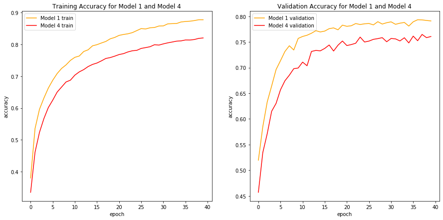

```python
plot_comparison(hist1, '1', hist4, '4')
```

#### Model 1 vs Model 4 analysis

A second evaluation will be conducted that replaces all kernel sizes with (5, 5) from (3, 3) to evaluate if the accuracy is improved.

### Model 5: Using (5, 5) kernel size for all convolutional layers

Model 5 is the same as Model 1 except the kernel size of the convolutional layers are (5, 5) for each convolutional layer.

```python
model5 = build_model(conv_unit_1=32,
                      conv_unit_2=64,
                      kernel_size_1=(5, 5),
                      kernel_size_2=(5, 5),
                      pool_size=(2, 2),
                      batch_norm=False,
                      dense_unit_1=512,
                      dense_unit_2=0)

model5 = compile_model(model5, 'Adam')
```

```python
hist5 = fit_model(model5, batch_size=128, epochs=40, validation_split=0.2)
```

```
Train on 40000 samples, validate on 10000 samples
```

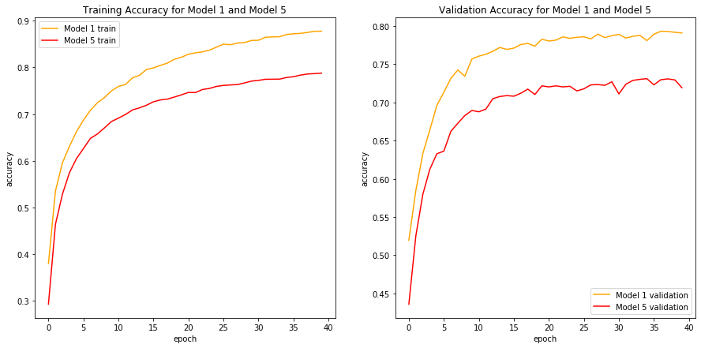

```python
plot_comparison(hist1, '1', hist5, '5')
```

#### Model 1 vs Model 5 analysis

While having a (5, 5) kernel size reduced the complexity of the model, one can see from the plots above the a (5, 5) kernel size also reduced the accuracy of the model by approximately 7%, to 71.94%.

For all future models, a kernel size of (3,3) will be used.

### Model 6: Doubling the number of filters in each convolutional layer

Model 6 is the same as Model 1 except the number of filters for each convolutional layer is doubled.

```python
model6 = build_model(conv_unit_1=64,
                      conv_unit_2=128,
                      kernel_size_1=(3, 3),
                      kernel_size_2=(3, 3),
                      pool_size=(2, 2),
                      batch_norm=False,
                      dense_unit_1=512,
                      dense_unit_2=0)

model6 = compile_model(model6, 'Adam')
```

```python
hist6 = fit_model(model6, batch_size=128, epochs=40, validation_split=0.2)
```

```
Train on 40000 samples, validate on 10000 samples
```

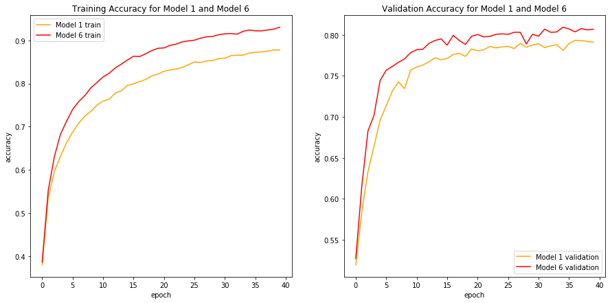

```python
plot_comparison(hist1, '1', hist6, '6')
```

#### Model 1 vs Model 6 analysis

Doubling the number of filters in each convolution increased the training time to approximately 120 seconds per epoch where the training time per epoch for Model 1 was less than 60 seconds. Doubling the number of filters in each convolution also increased the number of parameters from over 890,000 to over 1.9 million parameters. By doubling the number of filters in each convolution, the validation accuracy improved to 80.69% which is a 1.59% increase.

In the final model, the convolutional layers will each be doubled from the Model 1 values.

### Model 7: Adding batch normalization

Model 7 is the same as Model 1 except that batch normalization is performed before each pooling layer.

```python
model7 = build_model(conv_unit_1=32,
                      conv_unit_2=64,
                      kernel_size_1=(3, 3),
                      kernel_size_2=(3, 3),
                      pool_size=(2, 2),
                      batch_norm=True,
                      dense_unit_1=512,
                      dense_unit_2=0)

model7 = compile_model(model7, 'Adam')
```

```python
hist7 = fit_model(model7, batch_size=128, epochs=40, validation_split=0.2)
```

```
Train on 40000 samples, validate on 10000 samples
```

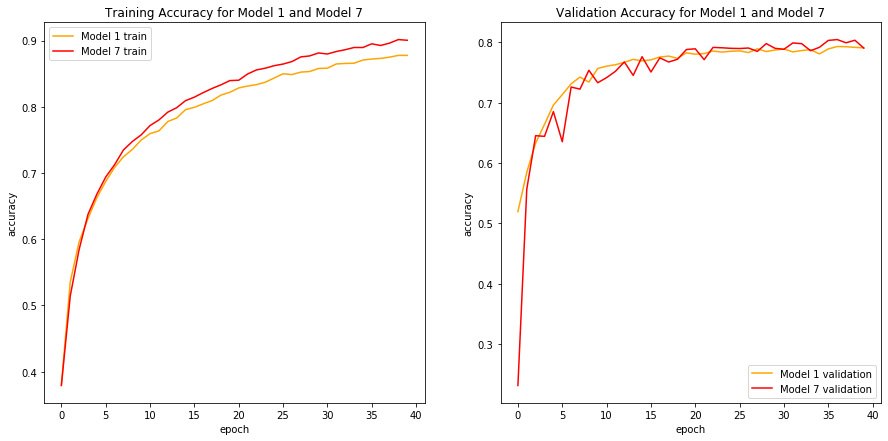

```python
plot_comparison(hist1, '1', hist7, '7')
```

#### Model 1 vs Model 7 analysis

By adding batch normalization, the model took approximately 15 more seconds per epoch to train than Model 1.

While adding batch normalization did not improve the final validation accuracy of Model 7, the validation accuracy was almost always higher than Model 1 after each model reached a plateau in validation accuracy.

Because Model 7 was able to achieve a max validation accuracy that was more than 1% higher than Model 1, batch normalization will be used in the final model.

### Model 8: Adding dense layer of 256 units

Model 8 is the same as Model 1 except that there is an additional dense layer of 256 units and 50% dropout after the dense layer of 512 units with 50% dropout.

```python
model8 = build_model(conv_unit_1=32,
                      conv_unit_2=64,
                      kernel_size_1=(3, 3),
                      kernel_size_2=(3, 3),
                      pool_size=(2, 2),
                      batch_norm=False,
                      dense_unit_1=512,
                      dense_unit_2=256)

model8 = compile_model(model8, 'Adam')
```

```python
hist8 = fit_model(model8, batch_size=128, epochs=40, validation_split=0.2)
```

```
Train on 40000 samples, validate on 10000 samples
```

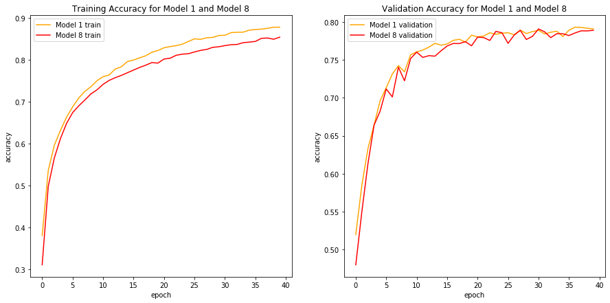

```python
plot_comparison(hist1, '1', hist8, '8')
```

#### Model 1 vs Model 8 analysis

Adding an additional fully connected layer before the softmax output resulted in a validation accuracy of 78.92% which is slightly below the validation accuracy of Model 1. An additional dense layer of 256 units with 50% dropout will not be added to the final model.

### Model 9: Adding dense layer of 1024 units

Model 9 is the same as Model 1 except that there is an additional dense layer of 1024 units and 50% dropout before the dense layer of 512 units with 50% dropout.

```python
model9 = build_model(conv_unit_1=32,
                      conv_unit_2=64,
                      kernel_size_1=(3, 3),
                      kernel_size_2=(3, 3),
                      pool_size=(2, 2),
                      batch_norm=False,
                      dense_unit_1=1024,
                      dense_unit_2=512)

model9 = compile_model(model9, 'Adam')
```

```python
hist9 = fit_model(model9, batch_size=128, epochs=40, validation_split=0.2)
```

```
Train on 40000 samples, validate on 10000 samples
```

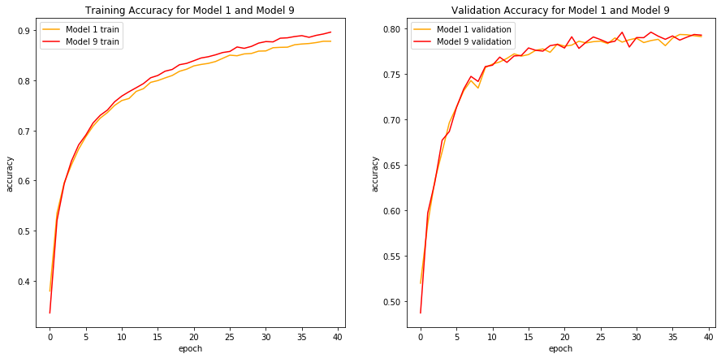

```python
plot_comparison(hist1, '1', hist9, '9')
```

#### Model 1 vs Model 9 analysis

While Model 8 did not have a higher validation accuracy than Model 1, Model 9 did have a validation accuracy that was 0.16% higher than Model 1.

The final model will include an additional dense layer of 1024 units with 50% dropout.

### Model 10: Using batch size of 256

Model 10 is the same as Model 1 except model 10 doubles the batch size from 128 to 256.

```python
model10 = build_model(conv_unit_1=32,
                      conv_unit_2=64,
                      kernel_size_1=(3, 3),
                      kernel_size_2=(3, 3),
                      pool_size=(2, 2),
                      batch_norm=False,
                      dense_unit_1=512,
                      dense_unit_2=0)

model10 = compile_model(model10, 'Adam')
```

```python
hist10 = fit_model(model10, batch_size=256, epochs=40, validation_split=0.2)
```

```
Train on 40000 samples, validate on 10000 samples
```

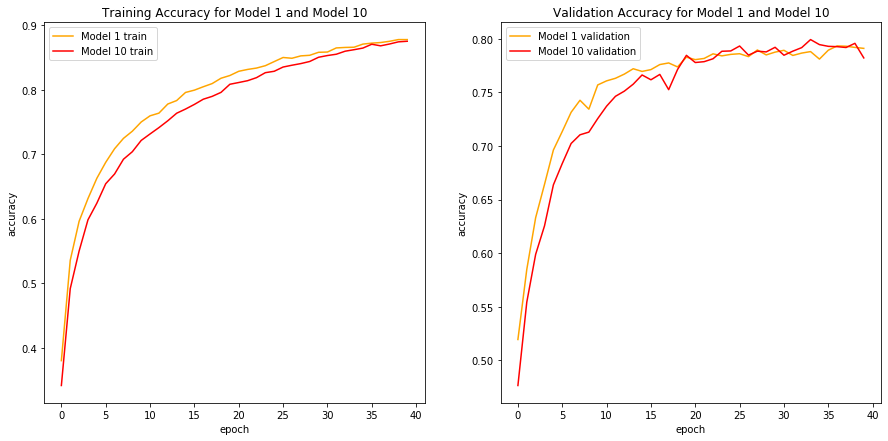

```python
plot_comparison(hist1, '1', hist10, '10')
```

#### Model 1 vs Model 10 analysis

Increasing the batch size to 256 reduced the training time by 10 seconds per epoch from Model 1. The validation accuracy changed more significantly between epochs than Model 1 and ended with a lower validation accuracy even though it had a higher validation accuracy than Model 1 in the last few epochs before the final epoch.

A batch size of 256 will not be used in the final model because the validation accuracy was not consistently higher than in Model 1.

### Model 11: Using batch size of 64

Model 11 is the same as Model 1 except the batch size is halved to 64.

```python
model11 = build_model(conv_unit_1=32,
                      conv_unit_2=64,
                      kernel_size_1=(3, 3),
                      kernel_size_2=(3, 3),
                      pool_size=(2, 2),
                      batch_norm=False,
                      dense_unit_1=512,
                      dense_unit_2=0)

model11 = compile_model(model11, 'Adam')
```

```python
hist11 = fit_model(model11, batch_size=64, epochs=40, validation_split=0.2)
```

```
Train on 40000 samples, validate on 10000 samples
```

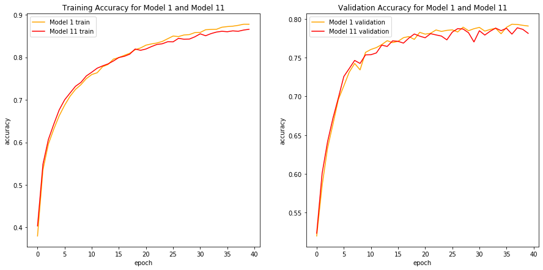

```python
plot_comparison(hist1, '1', hist11, '11')
```

#### Model 1 vs Model 11 analysis

Decreasing the batch size to 64 resulted in the validation accuracy reaching a plateau at a lower value than in Model 1. The final validation accuracy for Model 11 was 78.15%.

Since the validation accuracy was not improved, a batch size of 64 will not be used in the final model. This means that the final model will have a batch size of 128.

### Model 12: Using SGD optimizer

Model 12 is the same as Model 1 except it uses the SGD optimizer instead of the Adam optimizer.

```python
model12 = build_model(conv_unit_1=32,
                      conv_unit_2=64,
                      kernel_size_1=(3, 3),
                      kernel_size_2=(3, 3),
                      pool_size=(2, 2),
                      batch_norm=False,
                      dense_unit_1=512,
                      dense_unit_2=0)

model12 = compile_model(model12, 'SGD')
```

```python
hist12 = fit_model(model12, batch_size=128, epochs=40, validation_split=0.2)
```

```
Train on 40000 samples, validate on 10000 samples
```

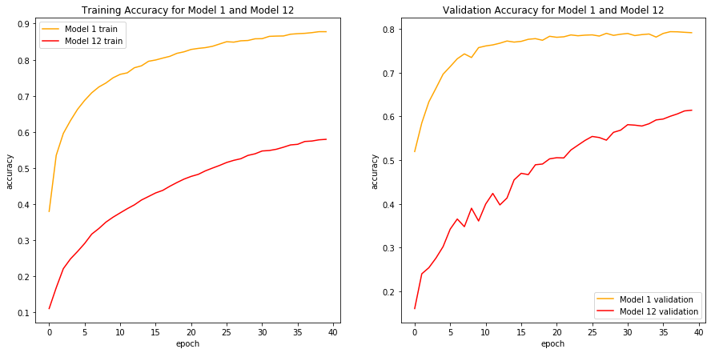

```python
plot_comparison(hist1, '1', hist12, '12')
```

#### Model 1 vs Model 12 analysis

Using the SGD optimizer yielded a significantly worse validation accuracy of 61.39%. The validation accuracy was most likely lower because the default parameters of the SGD optimizer are unfit to train the model on the CIFAR10 data. Perhaps lowering the learning rate to 0.001 from 0.01 would improve Model 12's performance.

The SGD optimizer will not be used in the final model.

### Model 13: Using Adadelta optimizer

Model 13 is the same as Model 1 except it uses the Adadelta optimizer instead of the Adam optimizer.

```python
model13 = build_model(conv_unit_1=32,
                      conv_unit_2=64,
                      kernel_size_1=(3, 3),
                      kernel_size_2=(3, 3),
                      pool_size=(2, 2),
                      batch_norm=False,
                      dense_unit_1=512,
                      dense_unit_2=0)

model13 = compile_model(model13, 'Adadelta')
```

```python
hist13 = fit_model(model13, batch_size=128, epochs=40, validation_split=0.2)
```

```
Train on 40000 samples, validate on 10000 samples
```

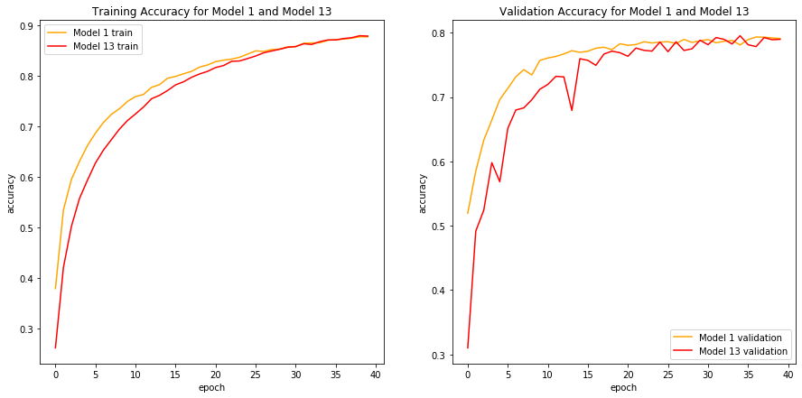

```python
plot_comparison(hist1, '1', hist13, '13')
```

#### Model 1 vs Model 13 analysis

Model 13 achieved a final validation accuracy of 78.97% which is slightly below the final validation accuracy for Model 1. Model 13 also appears to plateau at a lower value than Model 1.

The Adadelta optimizer will not be used in the final model.

### Model 14: Using RMSprop optimizer

Model 14 is the same as Model 1 except it uses the RMSprop optimizer instead of the Adam optimizer.

```python
model14 = build_model(conv_unit_1=32,
                      conv_unit_2=64,
                      kernel_size_1=(3, 3),
                      kernel_size_2=(3, 3),
                      pool_size=(2, 2),
                      batch_norm=False,
                      dense_unit_1=512,
                      dense_unit_2=0)

model14 = compile_model(model14, 'RMSprop')
```

```python
hist14 = fit_model(model14, batch_size=128, epochs=40, validation_split=0.2)
```

```
Train on 40000 samples, validate on 10000 samples
```

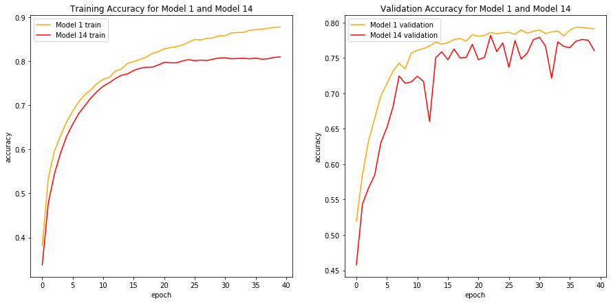

```python
plot_comparison(hist1, '1', hist14, '14')
```

#### Model 1 vs Model 14 analysis

Model 14 had a final validation accuracy of 76.02% which is more than 3% lower than Model 1. The validation accuracy of Model 14 appears to change quickly by very large amounts, which seems like the optimizer may be missing the local minimum of the cost function and then overcorrecting. Perhaps Model 14's performance could be improved by not using the default parameters for the RMSprop optimizer.

The RMSprop optimizer will not be used int he final model. This means that the Adam optimizer will be used in the final model.

### Plot comparison of Adam, SGD, Adadelta, and RMSprop optimizers

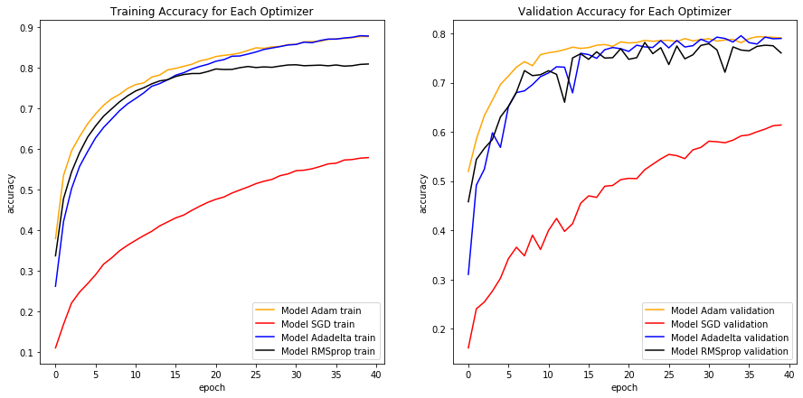

```python
fig, ax = plt.subplots(1, 2, figsize=(15, 7))

# Dictionary with optimizer names as keys and a list of hist and color as the values
optimizers = {'Adam': [hist1, 'orange', 'Adam'],
              'SGD': [hist12, 'r', 'SGD'],
              'Adadelta': [hist13, 'b', 'Adadelta'],
              'RMSprop': [hist14, 'k', 'RMSprop']}

for value in optimizers.values():
    ax[0].plot(value[0].history['accuracy'], label = 'Model {} train'.format(value[2]), color = value[1])
    ax[1].plot(value[0].history['val_accuracy'], label = 'Model {} validation'.format(value[2]), color = value[1])

ax[0].set_title('Training Accuracy for Each Optimizer')
ax[0].set_ylabel('accuracy')
ax[0].set_xlabel('epoch')
ax[0].legend()

ax[1].set_title('Validation Accuracy for Each Optimizer')
ax[1].set_ylabel('accuracy')
ax[1].set_xlabel('epoch')
ax[1].legend()

plt.show()
```

Above are the plots of the training and validation accuracies for all the different optimizers. From the validation accuracy plot, it is easy to see that the model using the Adam optimizer reaches the plateau first and almost always has a higher validation accuracy than the other models.

### Model 15: Using data augmentation

Model 15 is the same as Model 1 except that model 15 is trained using data augmentation to generate additional training data.

```python
batch_size = 128
epochs = 40
```

```python
model15 = build_model(conv_unit_1=32,
                      conv_unit_2=64,
                      kernel_size_1=(3, 3),
                      kernel_size_2=(3, 3),
                      pool_size=(2, 2),
                      batch_norm=False,
                      dense_unit_1=512,
                      dense_unit_2=0)

model15 = compile_model(model15, 'Adam')
```

```python
# Data Augmentation
datagen = ImageDataGenerator(
    featurewise_center=False,
    samplewise_center=False,
    featurewise_std_normalization=False,
    samplewise_std_normalization=False,
    zca_whitening=False,
    zca_epsilon=1e-06,
    rotation_range=0,
    width_shift_range=0.1,
    height_shift_range=0.1,
    shear_range=0.,
    zoom_range=0.,
    channel_shift_range=0.,
    fill_mode='nearest',
    cval=0.,
    horizontal_flip=True,
    vertical_flip=False,
    rescale=None,
    preprocessing_function=None,
    data_format=None,
    validation_split=0.2)
```

```python
train_generator = datagen.flow(
    x_train, y_train,
    batch_size=batch_size,
    subset='training')

validation_generator = datagen.flow(
    x_train, y_train,
    batch_size=batch_size,
    subset='validation')
```

```python
# Train the model
hist15 = model15.fit_generator(train_generator,
                                  epochs=epochs,
                                  validation_data=validation_generator,
                                  callbacks=None)
```

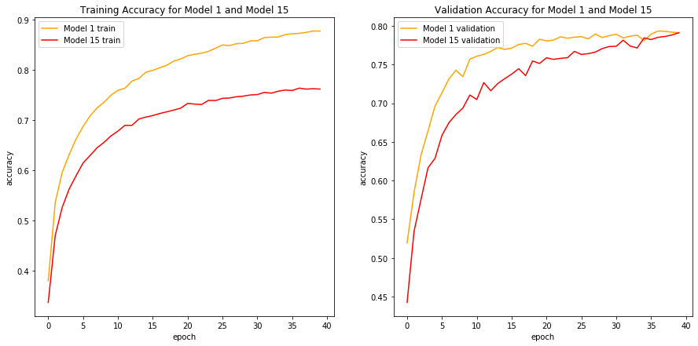

```python
plot_comparison(hist1, '1', hist15, '15')
```

#### Model 1 vs Model 15 analysis

Using the ImageDataGenerator function improved the performance by 0.02%. The validation accuracy was 79.12%. From the validation accuracy plot on the right, it appears that Model 15 has yet to reach a plateau and may even improve validation accuracy if it were to be trained for more epochs. It is also interesting to observe that the training accuracy of Model 15 is so low. A possible reason could be that it was not able to learn the patterns in the data as easily with more training data being used.

In the final model, data augmentation will be used, and the model will be trained for 60 epochs in the hopes of reaching a plateau in validation accuracy

### Final Model

Relative to all the models, Model 1 performed quite well. The models with improved validation accuracy were 3, 6, 9, and 15. The changes from Model 1 that are being included in the final model are: doubling the number of filters in each convolutional layer, adding a dense layer with 1024 units with 50% dropout before the dense layer of 512 units with 50% dropout, adding batch normalization, adding data augmentation, and training for 60 epochs

The final model hyperparameters and additional model aspects will be:

- epochs = 60
- batch_szie = 128
- optimizer = Adam
- kernel_size = (3, 3)
- pool_size = (2, 2)
- BatchNormalization
- DataAugmentation
- Number of filters in the first two convolutional layers = 64
- Number of filters in the second two convolutional layers = 128
- An additional dense layer of 1024 units will be used before the first dense layer in the Model 1

```python
batch_size = 128
epochs = 60
```

```python
model_final = build_model(conv_unit_1=64,
                      conv_unit_2=128,
                      kernel_size_1=(3, 3),
                      kernel_size_2=(3, 3),
                      pool_size=(2, 2),
                      batch_norm=True,
                      dense_unit_1=1024,
                      dense_unit_2=512)

model_final = compile_model(model_final, 'Adam')
```

```python
# Model Summary
model_final.summary()
```

```
Model: "sequential_16"
_________________________________________________________________
Layer (type)                 Output Shape              Param #
=================================================================
conv2d_60 (Conv2D)           (None, 30, 30, 64)        1792
_________________________________________________________________
conv2d_61 (Conv2D)           (None, 28, 28, 64)        36928
_________________________________________________________________
batch_normalization_3 (Batch (None, 28, 28, 64)        256
_________________________________________________________________
max_pooling2d_32 (MaxPooling (None, 14, 14, 64)        0
_________________________________________________________________
dropout_49 (Dropout)         (None, 14, 14, 64)        0
_________________________________________________________________
conv2d_62 (Conv2D)           (None, 12, 12, 128)       73856
_________________________________________________________________
conv2d_63 (Conv2D)           (None, 10, 10, 128)       147584
_________________________________________________________________
batch_normalization_4 (Batch (None, 10, 10, 128)       512
_________________________________________________________________
max_pooling2d_33 (MaxPooling (None, 5, 5, 128)         0
_________________________________________________________________
dropout_50 (Dropout)         (None, 5, 5, 128)         0
_________________________________________________________________
flatten_16 (Flatten)         (None, 3200)              0
_________________________________________________________________
dense_33 (Dense)             (None, 1024)              3277824
_________________________________________________________________
dropout_51 (Dropout)         (None, 1024)              0
_________________________________________________________________
dense_34 (Dense)             (None, 512)               524800
_________________________________________________________________
dropout_52 (Dropout)         (None, 512)               0
_________________________________________________________________
dense_35 (Dense)             (None, 10)                5130
=================================================================
Total params: 4,068,682
Trainable params: 4,068,298
Non-trainable params: 384
_________________________________________________________________
```

```python
# Data Augmentation
datagen = ImageDataGenerator(
    featurewise_center=False,
    samplewise_center=False,
    featurewise_std_normalization=False,
    samplewise_std_normalization=False,
    zca_whitening=False,
    zca_epsilon=1e-06,
    rotation_range=0,
    width_shift_range=0.1,
    height_shift_range=0.1,
    shear_range=0.,
    zoom_range=0.,
    channel_shift_range=0.,
    fill_mode='nearest',
    cval=0.,
    horizontal_flip=True,
    vertical_flip=False,
    rescale=None,
    preprocessing_function=None,
    data_format=None,
    validation_split=0.2)
```

```python
train_generator = datagen.flow(
    x_train, y_train,
    batch_size=batch_size,
    subset='training')

validation_generator = datagen.flow(
    x_train, y_train,
    batch_size=batch_size,
    subset='validation')
```

```python
# Train the model
hist_final = model_final.fit_generator(train_generator,
                                  epochs=epochs,
                                  validation_data=validation_generator,
                                  callbacks=None)
```

```python
print('history contains: ', hist_final.history)
```

[output not shown]

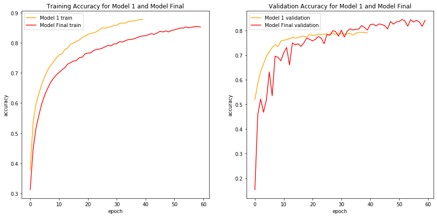

```python
plot_comparison(hist1, '1', hist_final, 'Final')
```

```python
score = evaluate_model(model_final, x_test, y_test)
```

```
Test loss: 0.4645257568359375
Test accuracy: 0.8453999757766724
```

#### Performance of the Final Model

The test accuracy of the final model is 84.53%. The combination of the different models that outperformed Model 1 was able to score a validation accuracy of 84.19% which was more than 5% better than the validation accuracy for Model 1.

I believe that incorporating data augmentation was able to significantly improve the accuracy of the model because the model was able to train on more data that was more representative of the test and validation data. It also appears that the validation data had yet to reach a plateau after training for 60 epochs. It would be interesting to train the model again for longer to see how the model's accuracy improves. The final model's validation accuracy increased steadily with occasionally large drops in validation accuracy. The changes in the validation accuracy for the final model changed much more significantly than the changes in validation accuracy for Model 1.

Overall, I am very pleased with the final model's performance, especially since the model was only trained on a laptop. The model even outperformed several neural networks listed on https://benchmarks.ai/cifar-10.

### Thoughts on model structure and hyperparameters in CNNs

#### Effect of batch size on model performance

An advantage to using smaller batches is that they are noisy and therefore can reduce a model's likelihood for overfitting to the training data. One of the downsides to using smaller batches is that they typically increase the amount of time required to train a model. For example, Model 10 (batch size of 264) had the fastest training time per epoch and Model 11 (batch size of 64) had the longest training time per epoch.

While having a smaller batch size typically improves model performance, that was not the case in Model 11 and so a batch size of 128 was used. One can see that using a smaller batch size does produce noisier results when looking at the validation accuracy plot for Model 11 vs Model 1. Model 11 has larger fluctuations in validation accuracy.

#### Importance of a fully connected layer between the convolutional outputs and the final softmax layer in a CNN

The benefit of having a fully connected layer between the convolutional outputs and the final softmax layer is that the fully connected layer can aggregate important features that are identified in different convolutional layers. If the fully connected layer was not used between the convolutional outputs and the final softmax layer, then the softmax layer would do a very poor job of classifying the different images because there would not be an easy way for the CNN to learn the connections between important features and the image's classification.

Based on the results from Model 9, it appears that adding another fully connected layer can further improve model performance though one should be weary of overfitting the model to the training data.

#### Why use categorical_crossentropy as the loss function?

Categorical cross-entropy loss was used when building the CNNs because of the benefits that cross-entropy loss has when evaluating outputs that are probabilities, and because there are 10 categories, or classes, that each image can be classified as for the CIFAR10 dataset. When a model classifies new data, each class is given a percent likelihood that the image belongs to the specific class. The further the percent likelihood is from 1 for the correct class, the larger the cross-entropy loss will be. In doing so, cross-entropy loss can punish incorrect classifications while rewarding correct classifications. While all loss functions punish incorrect classifications, cross-entropy loss punishes an incorrect classification the further the percent likelihood is from 1 exponentially. By having a larger loss value, the smaller the correct classification is, a model is punished much more for very incorrect classifications.

#### Importance of batch normalization in a CNN

Batch normalization is not a required layer in a CNN, but it is often worth implementing because batch normalization often improves the training accuracy of the model. Batch normalization normalizes the output from a previous activation layer and neural networks generally perform better on normalized data. The normalization is performed by subtracting each output by the mean of the batch and then dividing by the standard deviation of the batch. Once all the values in the batch have been normalized, then the following activation function can be used on the data.

#### Importance of dropout in a CNN

Dropout is the technique of randomly setting a fraction of the input values to zero for each pass through the neural network during training. Randomly dropping a fraction of the dataset forces the model to learn more general patterns in the data and the model cannot rely on consecutive layers of the neural network to overfit to the data.

Dropout is not necessary for designing a model, but it is a useful technique to limit overfitting a model to the training data.

#### Impact of Data Augmentation

The ImageDataGenerator function is a process for data augmentation. The input data is provided to the function and then the function will generate more images by manipulating the data in different ways. By producing many output images from one input image, there is more data to train the model on and each image looks entirely new to the model. The function is most commonly used to provide more training data so that more complex models can be created.

The danger of using data augmentation techniques is that the newly generated data may not accurately represent test data. If the generated data does not accurately represent test data, then the model's test accuracy will decrease.

### What would I do differently?

If I were to repeat this process again, I would want to evaluate some additional aspects of CNNs to try to further improve model performance:

- I would want to test different model architectures of different depths. There are many ways to build a model and I wonder if there are other model designs that could achieve better accuracy with less training or a smaller model size.
- I would want to explore the impact of other activation functions besides ReLU such as the LeakyReLU, PreLu, and ELU activation functions.
- I would want to explore using other optimizers and changing the hyperparameters of the optimizers.
- I would write a function to calculate the training time per model in order to more accurately compare models.
- I would want to explore how incorporating kernel sizes of (1, 1) would impact the model's accuracy. Kernel sizes of (1, 1) are often used to squeeze and expand feature maps with the intention of saving on computational cost,
- I would want to experiment with using average pooling instead of max pooling at the different pooling layers.